# Making a word prediction model in R

Pravesh Koirala

December 27, 2015

*To see the code for this project, go to this* [repository](https://github.com/PraveshKoirala/Dsscapstone)

## About

In this project, we document our effort to create a *next word prediction model* in R. We load our data and perform a preliminary analysis as well as create a mock n-gram model using a small sample of the data to illustrate the features of the data.

## Loading and exploring the data

The data used for this project can be acquired from this [link](https://d396qusza40orc.cloudfront.net/dsscapstone/dataset/Coursera-SwiftKey.zip).

After the data is downloaded, we can extract its content. There are three different text files each from different sources:

- Tweets
- News
- Blogs

Once the data is loaded, we perform some investigations

First, we take a look at some of our data samples.

Tweets,

```
## [1] "How are you? Btw thanks for the RT. You gonna be in DC anytime soon? Love to see you. Been way, way too long."
## [2] "When you meet someone special... you'll know. Your heart will beat more rapidly and you'll smile for no reason."
```

Blogs,

```
## [1] "In the years thereafter, most of the Oil fields and platforms were named after pagan gods."
## [2] "We love you Mr. Brown."
```

News,

```
## [1] "He wasn't home alone, apparently."
## [2] "The St. Louis plant had to close. It would die of old age. Workers had been making cars there since the onset of mass automotive production in the 1920s."
```

Overall, our data can be succintly summarized as follows:

|  | object_size_MB | lines_count | words_count |
| --- | --- | --- | --- |
| tweets | 301.3967 | 2360148 | 28013397 |
| blogs | 248.4935 | 899288 | 36434843 |
| news | 249.6329 | 1010242 | 33362287 |

## n-gram analysis

For the purpose of creating ngrams, we’ll be sampling from our data. Currently, we have sampled one percent from each of the file and aggregated them together to create our corpus.

Then we clean the text. This is done using the library `stringi` as it is extremely fast for string processing. The cleaning process involves

1. setting all words to lower cases
2. removing numbers and punctuations
3. profanity filtering

Then we create our ngram model using quatenda.

Some of the results that were observed are as follows:

The top 10 unigrams:

```
##    the     to    and      a     of     in      i   that     is    for
## 522158 284759 266985 249125 223178 174427 155743 112831 108655 108350
```

The top 10 bigrams

```
##   of_the   in_the   to_the   on_the  for_the    to_be   at_the  and_the
##    50014    44485    24051    20650    19555    16791    15015    14449
##     in_a with_the
##    12755    11825
```

Top 10 trigrams

```
##  one_of_the    a_lot_of     to_be_a  the_end_of some_of_the  out_of_the
##        3733        3166        1881        1807        1652        1634
## going_to_be  as_well_as    it_was_a  be_able_to
##        1600        1591        1530        1486
```

Similarly, the plot of the histograms for the corresponding n-grams upto trigrams are as follows:

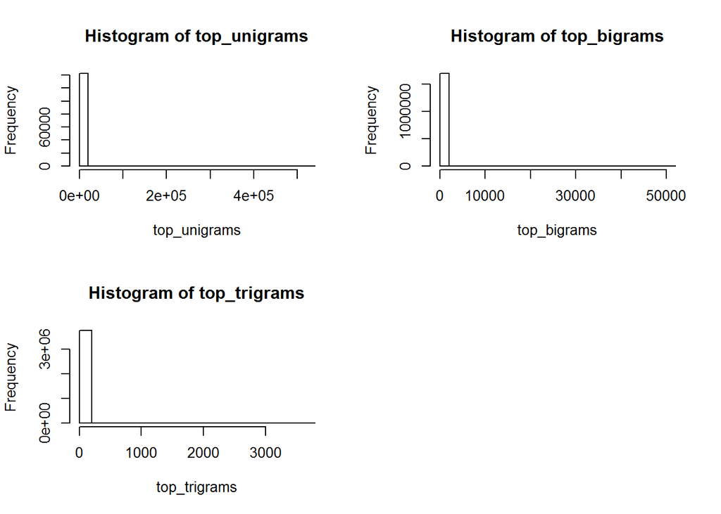

As can be seen from the plots, the histograms are greatly skewed towards some highly common n-grams.

## Plans for future

- Substitute equivalent words for the condensed ones.. i.e. i’ve to i have and so on
- Separate sentences.
- If possible, clean up the words further..
- Investigate some models like Good-Turing, HMM and even Stupid backoff for model building